# Lecture 16 Back Doors

Nick Huntington-Klein

March 3, 2019

## Recap

- We’ve now covered how to create causal diagrams
- (aka Directed Acyclic Graphs, if you’re curious what “dag”itty means)
- We simply write out the list of the important variables, and draw causal arrows indicating what causes what
- This allows us to figure out what we need to do to *identify* our effect of interest

## Today

- But HOW? How does it know?
- Today we’ll be covering the *process* that lets you figure out whether you can identify your effect of interest, and how
- It turns out, once we have our diagram, to be pretty straightforward
- So easy a computer can do it!

## The Back Door and the Front Door

- The basic way we’re going to be thinking about this is with a metaphor
- When you do data analysis, it’s like observing that someone left their house for the day
- When you do causal inference, it’s like asking *how they left their house*
- You want to *make sure* that they came out the *front door*, and not out the back door, not out the window, not out the chimney

## The Back Door and the Front Door

- Let’s go back to this example

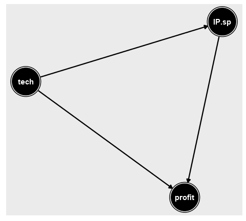

## The Back Door and the Front Door

- We’re interested in the effect of IP spend on profits. That means that our *front door* is the ways in which IP spend *causally affects* profits
- Our *back door* is any other thing that might drive a correlation between the two - the way that tech affects both

## Paths

- In order to formalize this a little more, we need to think about the various *paths*
- We observe that you got out of your house, but we want to know the paths you might have walked to get there
- So, what are the paths we can walk to get from IP.spend to profits?

## Paths

- We can go `Ip.spend -> profit`
- Or `IP.spend <- tech -> profit`

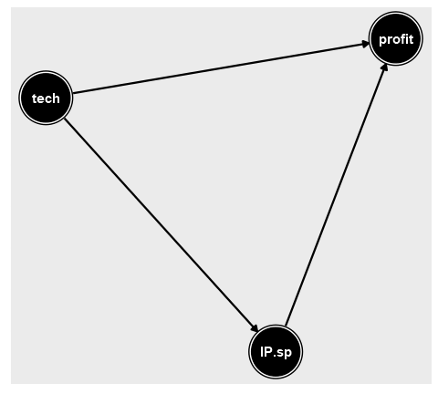

## The Back Door and the Front Door

- One of these paths is the one we’re interested in!
- `Ip.spend -> profit` is a *front door path*
- One of them is not!
- `IP.spend <- tech -> profit` is a *back door path*

## Now what?

- Now, it’s pretty simple!
- In order to make sure you came through the front door…
- We must *close the back door*
- We can do this by *controlling/adjusting* for things that will block that door!
- We can close `IP.spend <- tech -> profit` by adjusting for `tech`

## So?

- We already knew that we could get our desired effect in this case by controlling for `tech`.
- But this process lets us figure out what we need to do in a *much wider range of situations*
- All we need to do is follow the steps!
  - List all the paths
  - See which are back doors
  - Adjust for a set of variables that closes all the back doors!

## Example

- How does wine affect your lifespan?

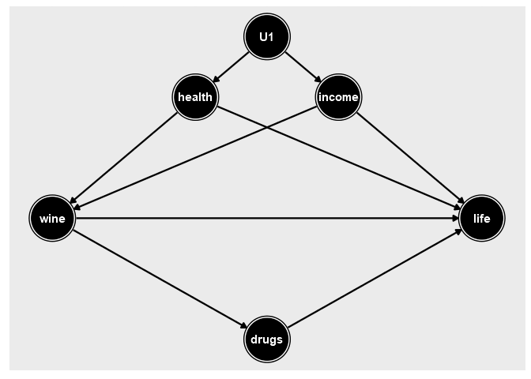

## Paths

- Paths from `wine` to `life`:
- `wine -> life`
- `wine -> drugs -> life`
- `wine <- health -> life`
- `wine <- income -> life`
- `wine <- health <- U1 -> income -> life`
- `wine <- income <- U1 -> health -> life`
- Don’t leave any out, even the ones that seem redundant!

## Paths

- Front doors/Back doors
- `wine -> life`
- `wine -> drugs -> life`
- `wine <- health -> life`
- `wine <- income -> life`
- `wine <- health <- U1 -> income -> life`
- `wine <- income <- U1 -> health -> life`

## Adjusting

- By adjusting for variables we close these back doors
- If an adjusted variable appears anywhere along the path, we can close that path off
- Once *ALL* the back door paths are closed, we have blocked all the other ways that a correlation COULD appear except through the front door! We’ve identified the causal effect!
- This is “the back door method” for identifying the effect. There are other methods; we’ll get to them.

## Adjusting for Health

- Front doors/Open back doors/Closed back doors
- `wine -> life`
- `wine -> drugs -> life`
- `wine <- health -> life`
- `wine <- income -> life`
- `wine <- health <- U1 -> income -> life`
- `wine <- income <- U1 -> health -> life`

## Adjusting for Health

- Clearly, adjusting for health isn’t ENOUGH to identify
- We need to adjust for health AND income
- We haven’t covered how to actually control for multiple variables
- We won’t be focusing on it, but it’s important for us to be able to know what *needs* to be controlled for

## Adjusting for Health and Income

- Front doors/Open back doors/Closed back doors
- `wine -> life`
- `wine -> drugs -> life`
- `wine <- health -> life`
- `wine <- income -> life`
- `wine <- health <- U1 -> income -> life`
- `wine <- income <- U1 -> health -> life`

## How about Drugs?

- Should we adjust for drugs?
- No! This whole procedure makes that clear
- It’s on a *front door path*
- If we adjusted for that, that’s shutting out part of the way that `wine` *DOES* affect `life`

## The Front Door

- In fact, remember, our real goal isn’t necessarily to close the back doors
- It’s to make sure you came through the front door!
- Sometimes (rarely), we can actually isolate the front door ourselves

## The Front Door

- Imagine this version

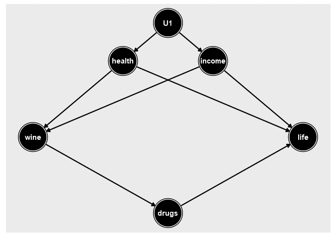

## The Front Door

- This makes it real clear that you shouldn’t control for drugs - that shuts the FRONT door! There’s no way to get out of your house EXCEPT through the back door!
- Note in this case that there’s no back door from `wine` to `drugs`
- And if we control for `wine`, no back door from `drugs` to `life` (let’s check this by hand)
- So we can identify `wine -> drugs` and we can identify `drugs -> life`, and combine them to get `wine -> life`!

## The Front Door

- This is called the “front door method”
- Much less common than the back door method, but actually older
- So we’ll only cover it briefly
- Historical relevance! This is similar to how they proved that cigarettes cause cancer

## Cigarettes and Cancer

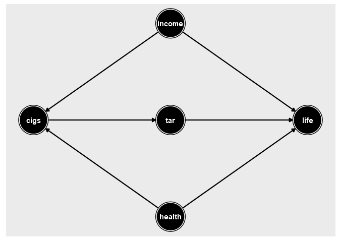

## Paths

- Closing these back doors is the problem that epidemiologists faced
- They can’t just run an experiment!
- Problem: there are actually MANY back doors we’re not listing
- And sometimes we can’t observe/control for these things
- How can you possibly measure “health” well enough to actually control for it?

## The Front Door Method

- So, noting that there’s no back door from `cigs` to `tar`, and then controlling for `cigs` no back door from `tar` to `cancer`, they combined these two effects to get the causal effect of `cigs` on `life`
- This is how we established this causal effect!
- Doctors had a decent idea that cigs caused cancer before, but some doctors disagreed
- And they had good reason to disagree! The back doors were VERY plausible reasons to see a `cigs`/`cancer` correlation other than the front door

## Practice

- We want to know how `X` affects `Y`. Find all paths and make a list of what to adjust for to close all back doors

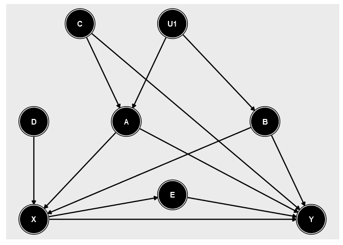

## Practice Answers

- Front door paths: `X -> Y`, `X -> E -> Y`
- Back doors: `X <- A -> Y`, `X <- B -> Y`, `X <- A <- U1 -> B -> Y`, `X <- B <- U1 -> A -> Y`, `X <- A <- C -> Y`, `X <- B <- U1 -> A <- C -> Y`
- (that last back door is actually pre-closed, we’ll get to that later)
- We can close all back doors by adjusting for `A` and `B`.